# Understanding the Durability of the Paul Biya Regime in Cameroon: A Micro-Level Approach Using Afrobarometer’s Round 7 National Survey

Adrien Ratsimbaharison and Benn Bongang

March 12, 2019

## Abstract

As of the writing of this paper, Paul Biya, who has been in power in Cameroon as a Prime Minister since 1975 and as a President since 1982, is the “longest-ruling non-royal national leader of the world.” While this durability has surprised many observers, it has not attracted a lot of attention from academia yet. In fact, the current literature on Cameroonian politics is generally focused on the dictatorial characteristics of the Biya regime, and not on the durability of the regime itself. The purpose of this paper is to fill this gap in the literature. Adopting a micro-level (or bottom-up) approach, we try to understand why the majority of the Cameroonian people are willing to stay under the same ruler for at least two generations. Using the data from the Afrobarometer’s round 7 national survey in Cameroon, we apply simple statistical analyses and machine learning (or predictive analytics) to find out to what extent the Cameroonian people support their president and his regime and to identify the predictors of such support. As a result, we find despite the so-called “Anglophone crisis” and Boko Haram’s attacks in the North, the majority of Cameroonians, especially the French speakers still approve the job performance of Paul Biya. Nevertheless, the main factors behind this approval have more to do with their trust in the president himself, the approval of the job performance of thei parliament members, and their regional location, than with the conduct of the political affairs of the country or the management of the national economy.

**Keywords:** Africa, Cameroon, political stability, regime durability, micro-level analysis, Afrobarometer national survey.

## Introduction

As a President, Paul Biya had to go through numerous difficulties and challenges. First, he survived a coup attempted by Ahidjo loyalists in April 1984. Next, following the introduction of multi-party system in Cameroon in the 1980s, he had to fight off a vigorous challenge by the opposition led by their charismatic leader, Ni John Fru Ndi, during the presidential election of 1992. Utimately, the most serious challenge to the survival of Paul Biya’s regime came in 2016, when teachers and lawyers of the Anglophone regions of the North-West and South-West began to strongly oppose the government’s drive to further marginalize the use of the English language in schools and courts. The ensuing street protests escalated into armed conflict when the military brutally attacked civilians and the separatists in these regions took arms to fight for the independence of their separate state, which was given the name of “Ambazonia.”

Despite its remarkable durability, the Paul Biya regime has not drawn a lot of academic interests yet. While there are numerous studies on the durability of autocratic regimes and survival of autocrats around the world, there are only a handful studies on Paul Biya and his regime. Thus, the purpose of this study is not only to fill this gap in the literature, but also to address specifically the question of why the majority of Cameroonians are still supporting the Paul Biya regime. In doing so, we will adopt a micro-level (or bottom-up) approach by trying to understand the factors that may have led to such support.

## Literature Review

For the most part, the contemporary literature on the Cameroonian politics focuses on the dictatorial characteristics of the Paul Biya regime, the division between the Anglophone part (North-West and South-West regions, making up about 20% of the country) and its Francophone part (the rest of the country), which led in recent years to a growing interest in the so-called “Anglophone crisis.” In line with this trend, very few studies have been devoted specifically to the durability of the Paul Biya regime, and there is not yet a commonly accepted explanation as to why it has lasted for more than three decades. Nevertheless, the broader literature on the durability of autocratic regime and survival of autocrats offer some insights that can help understand the durability of the Paul Biya regime.

With regard to the durability of the Paul Biya regime despite the growing political crisis in the North-West and South-West regions, in one of the few studies on this issue, Augustine Ayuk explains the stability of the Cameroonian political system with the following two factors:“a strong ruling party, the Cameroon National Union (CNU), and a strong individual, President Ahmadou Ahidjo” (Ayuk 2018). From a bottom-up approach and using statistical analysis based on its round 6 national survey on Cameroon, Afrobarometer underlines the fact that, even though most Cameroonians do not approve the economic policy of the government, they nevertheless think that the President has governed well the country in 2014 and they trust him (Afrobarometer 2015). This would explain why the majority of Cameroonians would vote for him and would not participate in street protests or marches that would overthrow his regime.

Turning to the broader literature on autocratic regime, we find that several authors identify “the use of political institutions” as one of the major factors that help autocratic regimes to endure and autocrats to survive. In line with this, to answer the question of why so-called “good leaders” do not stay in power for long times, while so-called “bad leaders” and dictators manage to do so, Bruce Bueno de Mesquita and others built a “theory on the selection of leaders,” and “show how political leaders allocate resources and how institutions for selecting leaders create incentives for leaders to pursue good and bad public policy” (Bueno de Mesquita et al. 2003). In the same vein, Jennifer Gandhi and Adam Przeworski argue that autocratic leaders rely on political institutions, such as legislatures, to “incorporate potential opposition forces, giving them a stake” in the survival of the regime (Gandhi and Przeworski 2007). Moreover, Marie-Eve Reny argues that autocratic rulers use the following “four mechanisms to control societal organizations: repression, coercion, cooptation and containment” (Reny, n.d.).

## Methodology

The durability of the Paul Biya regime has to do, not only with what the President himself and his cronies are doing (e.g., eliminating any pontential competitors, restraining political rights and civil liberties, etc.), but also with what the Cameroonians themselves think and do about the regime. In other words, we can reasonably think that some Cameroonians may genuinely support the regime or, at least, tolerate its existence to allow it to last for more than three decade. In this sense, we assume that those who support the regime would always vote for Paul Biya and would not participate in any actions (e.g., street protests) that would result in its termination.[^1] Accordingly, we adopt a micro-level (or bottom-up) approach to assess the level of popular support to the Paul Biya regime, and turn to the public opinion polls. Afrobarometer provides us reliable national surveys that can be used to assess this level of popular support.

Afrobarometer is “a pan-African, non-partisan research network that conducts public attitude surveys on democracy, governance, economic conditions, and related issues in more than 35 countries in Africa.” (Afrobarometer 2019a) Over the years, Afrobarometer’s surveys became one of the most trusted and reliable sources of information on African people’s opinions and attitudes toward their political and economic conditions, as well as their rulers. Cameroon was included in rounds 5, 6, and 7 of the national surveys conducted by Afrobarometer. Even if the surveys data do not directly address the questions about the durability of the Paul Biya regime, the data from they allow us to understand the Cameroonian people’s opinions and attitudes toward the president and his regime and explain why they are willing to stay under the same regime for so many years.

## Findings

### Descriptive Statistics

Afrobarometer’s round 7 national survey in Cameroon, which will be simply referred to as “Cameroon round 7 dataset” in this study, consists of the responses to 297 questions from 1204 respondents. In selecting these respondents, Afrobarometer used the so-called “national probability samples,” which were “designed to meet the following criteria[:] Samples are designed to generate a sample that is a representative cross-section of all citizens of voting age in a given country. The goal is to give every adult citizen an equal and known chance of being selected for an interview” (Afrobarometer 2019b). In the case of Cameroon, the following criteria were specifically taken into consideration in the selection of the respondents: gender, urban or rural locations, level of education, religion, and region (Afrobarometer 2015).

In this study, we will focus on the “approval of the way the President performed his job” (response question Q58A in Cameroon round 7 dataset) as a proxy for the support to the president and his regime, and as a dependent variable (or outcome variable) that may help understand the durability of Paul Biya’s regime. In this sense, we assume that the people who approve the way President Biya performs his job, tend also to vote for him, and let him stay in power as long as he wishes.

The Cameroon round 7 dataset reveal that the approval ratings of the presidential job performance in 2018 were actually high. As shown in Table 1 and Fig. 1, with 37.79% of the respondents “approving” and 18.27% “strongly approving”, the total approval ratings of 56.06%. This is in comparison to the total disapproval ratings, which were only 33.47%, with 15.28% of the respondents “strongly disapproving” and 18.19% “disapproving.[^2]

### The Predictors of Paul Biya’s Approval Ratings

In this section, we use machine learning (or statistical learning) to identify the predictors (or determinants) of Paul Biya’s approval ratings. In doing so, we follow the guidelines suggested by different data scientists who specialize in the use r statistical and programming language and particularly the Caret package, created and maintained by Max Kuhn (Kuhn 2015; Kuhn 2012; Kuhn 2008). Among these guidelines, we found particularly useful Saurav Kaushik’s “Practical guide to implement machine learning with CARET in R” (2016) and Brett Lanz’s “Machine Learning with R” (2015). After the initial step of installing the Caret package and loading the dataset into r, the implementation of machine learning using the caret package in r generally includes the following:

- defining the problem,
- preprocessing the data if necessary,
- spliting the data into train and test sets,
- feature selection using the “recursive feature elimination”" or “rfe”" function,
- traning the models on the train set,
- generating variable importance,
- making predictions on the test set and assessing the accuracy of the predictions.[^6]

As noted earlier, to simplify the data analyses and facilitate the interpretation of the findings, we mutate the variable “Q58A”, which has six levels into a new variable “approval” which only has three levels, by combining “strongly disapprove” and “disapprove” as “disapproval”, “approve” and “strongly approve” as “approval”, and “no answer” and “don’t know” as “don’t know”. We are exclusively using the new variable “approval” in the following machine learning implementation.

Thus, the problem in this machine learning is to predict the “approval” of Paul Biya’s job performance (i.e, the responses to the mutated variable Q58A of the Cameroon Round 7 survey (“Do you approve or disapprove of the way that the President has performed his jobs over the past 12 months?”). In other words, we are dealing here with a machine learning classification into three categories:

- “disapproval” (for those who simply “disapprove” or “strongly dispprove” the way the President has performed his job),
- “approval” (for those who simply “approve” or “strongly approve” the way the President has performed his job)
- “don’t know” (for those who refuse to answer the question or don’t know whether to approve or not the way the President has performed his job)

Since we are mainly dealing with categorical variables, with the expection of the “age” of the respondents which can be left as it is (as there are no major variation of the ages), we do not need to preprocess the data by centering and scaling the variables, and running a “principal component analysis” (pca). Accordingly, we directly proceed to randomize and split the data following the above definition of problem. In doing so, we Split the dataset into train Set and test Set based on the new variable “approval”, which is set as the outcome variable (or dependent variable), with a ratio of 75% and 25%.

The first machine learning procedure we run is the feature selection which leads to the computation of the number of variables that would be required to obtain the highest accuracy in the predictions and the identification of the top five variables. The output of the feature selection, using the “recursive feature elimination” (*rfe*) function in Caret, is as follows:

- 16 variables out of 286 would result in a 73.85% prediction accuracy, and
- The top five variables (out of 16) are:
  - Q58B (“Do you approve or disapprove of the way that *your member of Parliament* has performed *her/his* jobs over the past 12 months?”),
  - Q43A (“How much do you trust *the President*, or haven’t you heard enough about *him* to say?”),
  - Q58C (“Do you approve or disapprove of the way that *your elected local government councillor* has performed *her/his* jobs over the past 12 months?”),
  - REGION (regional location of the respondent),
  - Q99 (“If presidential elections were held tomorrow, which party’s candidate would you vote for?”).[^7]

We train the following two commonly used models for classification on the training set: Gradient Boosting Machines (GBM) and Random Forest (RF). Since the GBM model generates the highest predition accuracy of these two models, we focus on the results from this model in this study.

These variables correspond to the responses to the following questions:

- Q58B(1 to 9): “Do you approve or disapprove of the way that *your member of Parliament* has performed *her/his* jobs over the past 12 months?”
- Q43A(1 to 9): “How much do you trust *the President*, or haven’t you heard enough about *him* to say?”
- Q36(1 to 9): “Overall, how satisfied are you with the way democracy works in Cameroon?”
- REGION: Regional location of the respondent
- Q32(1 to 9): “Do you agree with the following statements? Statement 1: Parliament should ensure that the president explains to it on a regular basis how his government spends taxpayers’ money. Statement 2: The president should be able to devote his full attention to developing the country rather than wasting time justifying his actions.”
- Q43G3: “How much do you trust *the police*, or haven’t you heard enough about *him* to say?”
- Q99(1220 to 9999): “If presidential elections were held tomorrow, which party’s candidate would you vote for?”
- Q58D(1 to 9): “Do you approve or disapprove of the way that *your traditional leader* has performed *her/his* jobs over the past 12 months?”
- Q44A(1 to 9): “How [often] do you think [the president was] involved in corruption, or haven’t you heard enough about them to say?”
- Q44K_CAM(1 to 9): “How [often] do you think [the customs officers were] involved in corruption, or haven’t you heard enough about them to say?”
- Q26E(1 to 9): “whether you, personally, have [participated in a demonstration or protest march] during the past year”
- Q24B(0 to 9): “Did you work for a candidate or party [during the last national election in 2013]?”
- Q1: “How old are you?”
- Q42E(1 to 9): “In your opinion, how often, in this country, do officials who commit crimes go unpunished?”

Finally, in predicting the outcome variable “approval” on the test set, using the trained GBM model, we obtain an accuracy of 73.91 %.[^9]

In sum, with a relatively high accuracy, we can predict the approval of Paul Biya’s job performance, based on the responses of the respondents to questions that have to do mainly with the following factors:

- approval of the job performance of their member of Parliament,
- trust in the president himself,
- satisfaction with the way democracy works in Cameroon,
- regional location.

## Discussion and Conclusion

- approval of the job performances of the members of the Parliament (responses to questions Q58B3 and Q58B9 of *cam_round7*),
- trust in the President (responses to question Q43A of *cam_round7*),
- regional location of the respondent (responses to question REGION of *cam_round7*).

In other words, the approval rating of President Paul Biya was not based on his performance in managing the national economy, nor in handling the various political problems of the country (such as the crisis in Anglophone regions and the Boko Haram’s attacks in the North), but on whether the respondents trusted him, approved the job of the members of the Parliament, or come from other regions than the North-West and the South-West.

In this sense, we can explained the durability of the Paul Biya regime, not only based on what the regime is doing to repress the opposition, but also based on the personal connection or affinity between the Cameroonians and their President and members of the Parliament.

## Tables and Figures

Table 1 - Approval Ratings of President Paul Biya’s Job Performance at the National Level (2018)

| Approval Scale | Percentage |
| --- | --- |
| 1. Strongly disapprove | 15.28% |
| 2. Disapprove | 18.19% |
| 3. Approve | 37.79% |
| 4. Strongly approve | 18.27% |
| 5. Don’t know | 10.46% |

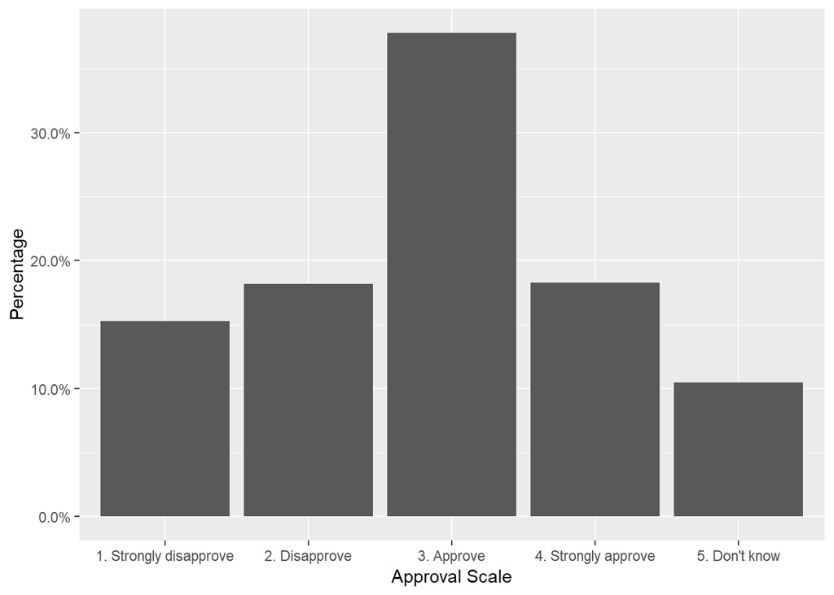

Fig. 1 - Approval Ratings of Paul Biya’s Job Performance at the National Level (2018)

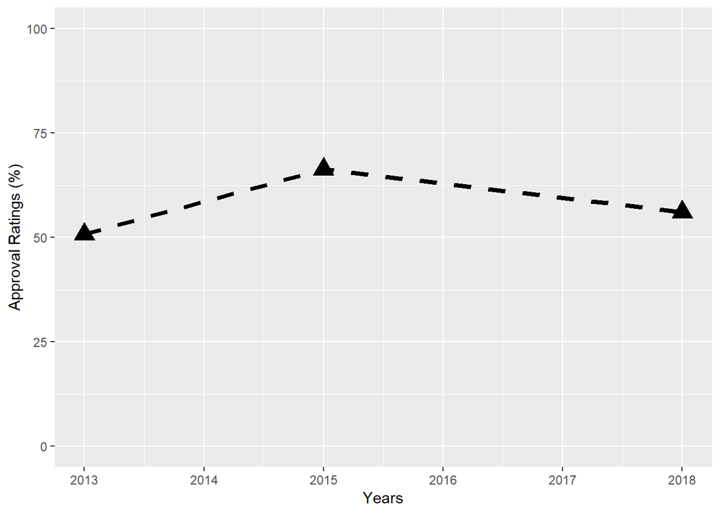

Fig. 2 - Approval Ratings Trend of Paul Biya’s Job Performance from 2013 to 2018

Table 2 - Approval Ratings of Paul Biya’s Job Performance by Region (2018)

| Region | Transformed Approval Scale | Count | Percentage |
| --- | --- | --- | --- |
| 1. Yaounde | Approve | 69 | 57 |
| 1. Yaounde | Disapprove | 36 | 30 |
| 1. Yaounde | Don’t know | 17 | 14 |
| 10. West | Approve | 43 | 41 |
| 10. West | Disapprove | 42 | 40 |
| 10. West | Don’t know | 19 | 18 |
| 11. South | Approve | 32 | 80 |
| 11. South | Disapprove | 8 | 20 |
| 12. South West | Approve | 9 | 10 |
| 12. South West | Disapprove | 57 | 64 |
| 12. South West | Don’t know | 23 | 26 |
| 2. Douala | Approve | 72 | 53 |
| 2. Douala | Disapprove | 48 | 35 |
| 2. Douala | Don’t know | 16 | 12 |
| 3. Adamawa | Approve | 50 | 78 |
| 3. Adamawa | Disapprove | 13 | 20 |
| 3. Adamawa | Don’t know | 1 | 2 |
| 4. Center | Approve | 70 | 67 |
| 4. Center | Disapprove | 28 | 27 |
| 4. Center | Don’t know | 6 | 6 |
| 5. East | Approve | 30 | 75 |
| 5. East | Disapprove | 5 | 12 |
| 5. East | Don’t know | 5 | 12 |
| 6. Extreme-North | Approve | 162 | 75 |
| 6. Extreme-North | Disapprove | 50 | 23 |
| 6. Extreme-North | Don’t know | 4 | 2 |
| 7. Littoral | Approve | 27 | 56 |
| 7. Littoral | Disapprove | 17 | 35 |
| 7. Littoral | Don’t know | 4 | 8 |
| 8. North | Approve | 97 | 71 |
| 8. North | Disapprove | 37 | 27 |
| 8. North | Don’t know | 3 | 2 |
| 9. North West | Approve | 14 | 13 |
| 9. North West | Disapprove | 62 | 60 |
| 9. North West | Don’t know | 28 | 27 |

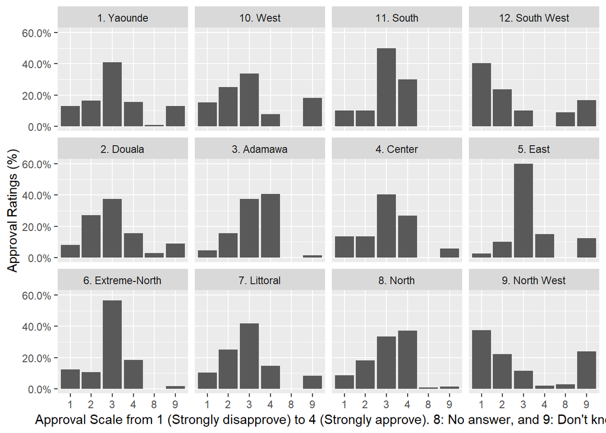

Fig. 3 - Approval Ratings of Paul Biya’s Job Performance by Regions (2018)

## Appendices

Table A.1 - Voting Intention for the general population

| Voting Intention | Proportion |
| --- | --- |
| 1. Vote for the President | 0.4509967 |
| 2. Vote for other candidates | 0.0797342 |
| 3. Don’t know | 0.4692691 |

Table A.2 - Voting Intention Among Paul Biya’s Supporters

| Voting Intention | Proportion |
| --- | --- |
| 1. Vote for the President | 0.6133333 |
| 2. Vote for other candidates | 0.0429630 |
| 3. Don’t know | 0.3437037 |

Table B1 - Participation in Street Protests for the General Population

| Participation in Street Protests | Proportion |
| --- | --- |
| Don’t know | 0.0423588 |
| No | 0.8397010 |
| Yes | 0.1179402 |

Table B.2 - Participation in Street Protests among the Paul Biya Supporters

| Participation in Street Protests | Proportion |
| --- | --- |
| Don’t know | 0.0325926 |
| No | 0.8696296 |
| Yes | 0.0977778 |

## References

Afrobarometer. 2015. “Résultats de La Sixième Enquête AFROBAROMETER Au Cameroun.” http://afrobarometer.org/sites/default/files/media-briefing/cameroon/cam_r6_presentation1_les_institutions_au_Cameroun_16122015.pdf.

———. 2019a. “About Afrobarometer.” http://afrobarometer.org/about.

———. 2019b. “Sampling Principles and Weighting.” https://www.afrobarometer.org/surveys-and-methods/sampling-principles.

Ayuk, Augustine E. 2018. “The Roots of Stability and Instability in Cameroon.” In *Post-Colonial Cameroon: Politics, Economy, and Society*, edited by Joseph Takougang and Julius A. Amin, 43–64. Lahman, MD: Lexington Books.

Bueno de Mesquita, Bruce, Alastair Smith, Randolph M. Siverson, and James D. Morrow. 2003. *The Logic of Political Survival*. Boston, MA: The MIT Press. doi:10.7551/mitpress/4292.001.0001.

Gandhi, Jennifer, and Adam Przeworski. 2007. “Authoritarian Institutions and the Survival of Autocrats.” *Comparative Political Studies* 40 (11): 1279–1301.

Kaushik, Saurav. 2016. “Practical Guide to Implement Machine Learning with CARET in R.” *Analytics Vidhya*. December 8. https://www.analyticsvidhya.com/blog/2016/12/practical-guide-to-implement-machine-learning-with-caret-package-in-r-with-practice-problem/.

Kuhn, Max. 2008. “Building Predictive Models in R Using the Caret Package.” *Journal of Statistical Software* 28 (5): 1–26.

———. 2012. “The Caret Package.” http://citeseerx.ist.psu.edu/viewdoc/download?doi=10.1.1.216.2142&rep=rep1&type=pdf.

———. 2015. “A Short Introduction to the Caret Package.” http://citeseerx.ist.psu.edu/viewdoc/download?doi=10.1.1.398.4352&rep=rep1&type=pdf.

Lantz, Brett. 2015. *Machine Learning with R*. 2 edition. Birmingham, UK: Packt Publishing.

O’Donnell, Jefcoate, and Robbie Gramer. 2018. “Cameroon’s Paul Biya Gives a Master Class in Fake Democracy.” *Foreign Policy*, October 22. https://foreignpolicy.com/2018/10/22/cameroons-paul-biya-gives-a-master-class-in-fake-democracy/.

Reny, Marie-Eve. n.d. “Autocracies and the Control of Societal Organizations.” *Government and Opposition*, 1–20. doi:10.1017/gov.2019.7.

Tchouteu, Janvier, Janvier Chouteu-Chando, and Janvier T. Chando. 2017a. *CAMEROON: The Haunted Heart of Africa*. Independently published.

———. 2017b. *Cameroon: France’s Dysfunctional Puppet System in Africa*. New York, NY: TISI Books.

———. 2018. *Paul Biya of Cameroon: Three-Plus Decades of Misrule Under an Anachronistic French-Imposed System*. New York, NY: TISI Books.